# act_report

## Report: act_report

### Analyzing and Visualizing the data

After going through the wrangling process (gathering, assessing, cleaning) and then storing the cleaned data in a master dataframe, the data can now be analyzed to generate insights and visualization. </br> In order to get insights from the data, we queried the data set a bit. From these queries, we had some information which includes:

- Tweets that have one image were mostly predicted and from the confidence level of the predictions, we had more of them as dog i.e *True*
- The mean of the first prediction confidence is approximately 60% and the minimum and maximum value were 4.4% and 100% respectively.
- The average retweet count was 2900 and the average favorite count was 9049.
- Of the four stages, we have more dogs that were classified as pupper, which from the definitions are dogs that are young and small and not so inexperienced. Can also be classified as the dog equivalent of a baby.

Three questions were posed in order to gain some more insights on the data and with the aid of some visuals, we were able to represent these questions.

#### Q1: What dog stage has the highest count?

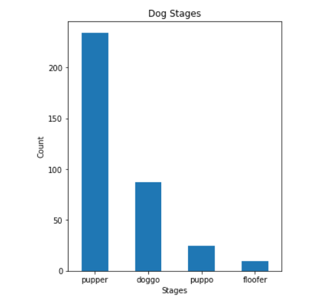

As was earlier mentioned, more dogs were classified as **pupper** than other stages. Though the data of the dog stages is incomplete as we have over 80% missing values, due to this we cannot ascertain the validity of this insight. Below is an example of a dog classified as a **pupper**

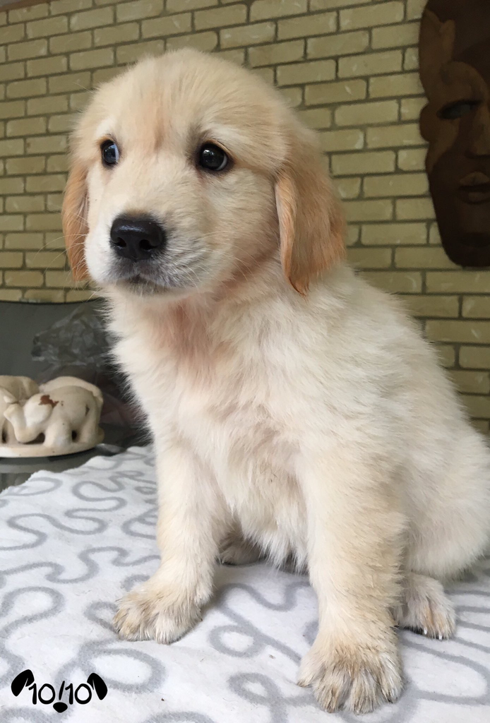

#### Q2: What image number occured most and how accurate was it prediction as a dog?

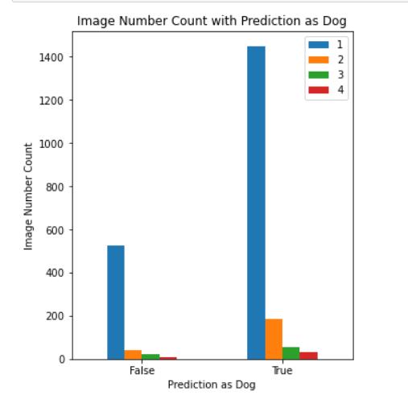

Tweets that had one image were mostly predicted through the neural network. And they had the highest count of prediction as dogs to be true.

#### Q3: What kind of correlation exists between the favourite count and retweet count

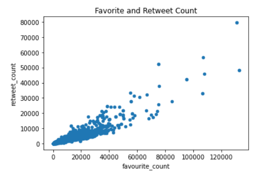

The above shows a positive correlation between the retweet_count and the favorite_count.

#### In conclusion:

From the analysis, insights, and visualizations of the dataset:

- The data would actually require more wrangling to draw more insights.
- Missing data of the dog stages leaves us with an unconfirmed analysis.